# Craniosynostosis Combined Model RNAseq Filtering

Samantha Lapehn Young

4/18/2022

## Craniosynostosis RNAseq- Data Filtering

This code performs data filtering and pre-processing for the Cunningham Lab/Paquette Lab-Craniosynostosis RNAseq project which evaluates gene expression differences in primary osteoblasts across four phenotypes of single suture craniosynostosis (Metopic, Coronal, Sagittal, Lambdoid) compared to unaffected controls.

## Load Packages

```r
library(biomaRt)
library(org.Hs.eg.db)
library(tidyverse)
library(edgeR)
```

## Load Covariate Data

Loading covariate data for samples that had sequencing data. All samples with NAs were removed prior to uploading. Turn sample ID into a character variable and add as rownames.

```r
CranioCovariates <- read.csv("/Volumes/paquette_a/slapehn/CranioRNAseq/Cranio_CovariateData.csv")

CranioCovariates$Sample_ID <- as.character(CranioCovariates$Sample_ID)
rownames(CranioCovariates) <- CranioCovariates$Sample_ID
dim(CranioCovariates)
```

```
## [1] 473  14
```

```r
CranioCovariates <- na.omit(CranioCovariates)

dim(CranioCovariates)
```

```
## [1] 473  14
```

## Load RNAseq Count Data and make into matrix

Loading count data with rownames as entrez gene IDs. Removing three participants that have missing covariate data.

```r
load("/Volumes/paquette_a/slapehn/CranioRNAseq/MCCranio_RawCountsfromSubrread4152022.RData")
as.character(colnames(Counts))
```

```
##   [1] "163499" "163500" "163501" "163502" "163503" "163504" "163505" "163506"
##   [9] "163507" "163508" "163509" "163510" "163511" "163512" "163513" "163514"
##  [17] "163515" "163516" "163517" "163518" "163519" "163520" "163521" "163522"
##  [25] "163523" "163524" "163525" "163526" "163527" "163528" "163529" "163530"
##  [33] "163531" "163532" "163533" "163534" "163535" "163536" "163537" "163538"
##  [41] "163539" "163540" "163541" "163542" "163543" "163544" "163545" "163546"
##  [49] "163547" "163548" "163549" "163550" "163551" "163552" "163553" "163554"
##  [57] "163555" "163556" "163557" "163558" "163559" "163560" "163561" "163562"
##  [65] "163563" "163564" "163565" "163566" "163567" "163568" "163569" "163570"
##  [73] "163571" "163572" "163573" "163574" "163575" "163576" "163577" "163578"
##  [81] "163579" "163580" "163581" "163582" "163583" "163584" "163585" "163586"
##  [89] "163587" "163588" "163589" "163590" "163591" "163592" "163593" "163594"
##  [97] "163595" "163596" "163597" "163598" "163599" "163600" "163601" "163602"
## [105] "163603" "163604" "163605" "163606" "163607" "163608" "163609" "163610"
## [113] "163611" "163612" "163613" "163614" "163615" "163616" "163617" "163618"
```

[output cut: 45 more lines]

```r
as.character(rownames(Counts))
```

```
##     [1] "1"         "10"        "100"       "1000"      "10000"     "100008586"
##     [7] "100008587" "100008588" "100008589" "100009613" "100009676" "10001"
##    [13] "10002"     "10003"     "100033413" "100033414" "100033415" "100033416"
##    [19] "100033417" "100033418" "100033419" "100033420" "100033421" "100033422"
##    [25] "100033423" "100033424" "100033425" "100033426" "100033427" "100033428"
##    [31] "100033429" "100033430" "100033431" "100033432" "100033433" "100033434"
##    [37] "100033435" "100033436" "100033437" "100033438" "100033439" "100033440"
##    [43] "100033441" "100033442" "100033443" "100033444" "100033445" "100033446"
##    [49] "100033447" "100033448" "100033449" "100033450" "100033451" "100033453"
##    [55] "100033454" "100033455" "100033456" "100033458" "100033460" "100033603"
##    [61] "100033799" "100033800" "100033801" "100033802" "100033803" "100033804"
##    [67] "100033805" "100033806" "100033807" "100033808" "100033809" "100033810"
##    [73] "100033811" "100033812" "100033813" "100033814" "100033815" "100033816"
##    [79] "100033817" "100033818" "100033819" "100033820" "100033821" "100033822"
##    [85] "100036519" "100036563" "100036564" "100036565" "100036566" "100036567"
```

[output cut: 4269 more lines]

```r
#Removing three participants without full covariate data
Counts$"163629" <- NULL
Counts$"163630" <- NULL
Counts$"95689" <- NULL
Count_Matrix <- data.matrix(Counts)
```

##Create an annotation file using BioMart Create annotation file with Entrez gene IDs to match the gene identifier in the count data

```r
mart <- useDataset("hsapiens_gene_ensembl", useMart("ensembl"))
```

```
## Ensembl site unresponsive, trying useast mirror
```

```r
annot <- biomaRt::getBM(filters= "entrezgene_id", attributes=c("ensembl_gene_id","description","gene_biotype","hgnc_id","hgnc_symbol","entrezgene_id"), values=rownames(Count_Matrix), mart=mart)

annot <-na.omit(annot)
annot <-annot [!duplicated(annot$ensembl_gene_id),]
annot<- annot[!duplicated(annot$entrezgene_id),]
rownames(annot )<-as.character(annot$entrezgene_id)
```

## Entrez to Ensembl Gene Name Conversion

Switching gene identifiers from Entrez gene IDs to ensembl Gene IDs because Entrez gene IDs get confused as being integers.

```r
Counts$Entrez <- rownames(Counts)
annot$Entrez <- rownames(annot)
Entrez_Ensembl_Map <- annot %>%
  dplyr::select(ensembl_gene_id, Entrez)

Counts_Ensembl <- inner_join(Entrez_Ensembl_Map, Counts, by=c("Entrez"="Entrez"))
annot$Entrez <- NULL
rownames(annot) <- as.character(annot$ensembl_gene_id)
rownames(Counts_Ensembl) <- Counts_Ensembl$ensembl_gene_id
Counts_Ensembl_Ready <- subset(Counts_Ensembl, select = -c(Entrez, ensembl_gene_id))
Count_Matrix_Final <- data.matrix(Counts_Ensembl_Ready)
```

##Check: Make sure sample info and gene names are aligned

```r
intersect(colnames(Count_Matrix_Final),rownames(CranioCovariates))
```

```
##   [1] "163499" "163500" "163501" "163502" "163503" "163504" "163505" "163506"
##   [9] "163507" "163508" "163509" "163510" "163511" "163512" "163513" "163514"
##  [17] "163515" "163516" "163517" "163518" "163519" "163520" "163521" "163522"
##  [25] "163523" "163524" "163525" "163526" "163527" "163528" "163529" "163530"
##  [33] "163531" "163532" "163533" "163534" "163535" "163536" "163537" "163538"
##  [41] "163539" "163540" "163541" "163542" "163543" "163544" "163545" "163546"
##  [49] "163547" "163548" "163549" "163550" "163551" "163552" "163553" "163554"
##  [57] "163555" "163556" "163557" "163558" "163559" "163560" "163561" "163562"
##  [65] "163563" "163564" "163565" "163566" "163567" "163568" "163569" "163570"
##  [73] "163571" "163572" "163573" "163574" "163575" "163576" "163577" "163578"
##  [81] "163579" "163580" "163581" "163582" "163583" "163584" "163585" "163586"
##  [89] "163587" "163588" "163589" "163590" "163591" "163592" "163593" "163594"
##  [97] "163595" "163596" "163597" "163598" "163599" "163600" "163601" "163602"
## [105] "163603" "163604" "163605" "163606" "163607" "163608" "163609" "163610"
## [113] "163611" "163612" "163613" "163614" "163615" "163616" "163617" "163618"
```

[output cut: 45 more lines]

```r
CranioCovariates<-CranioCovariates[colnames(Count_Matrix_Final),]

rownames(CranioCovariates)==colnames(Count_Matrix_Final)
```

```
##   [1] TRUE TRUE TRUE TRUE TRUE TRUE TRUE TRUE TRUE TRUE TRUE TRUE TRUE TRUE TRUE
##  [16] TRUE TRUE TRUE TRUE TRUE TRUE TRUE TRUE TRUE TRUE TRUE TRUE TRUE TRUE TRUE
##  [31] TRUE TRUE TRUE TRUE TRUE TRUE TRUE TRUE TRUE TRUE TRUE TRUE TRUE TRUE TRUE
##  [46] TRUE TRUE TRUE TRUE TRUE TRUE TRUE TRUE TRUE TRUE TRUE TRUE TRUE TRUE TRUE
##  [61] TRUE TRUE TRUE TRUE TRUE TRUE TRUE TRUE TRUE TRUE TRUE TRUE TRUE TRUE TRUE
##  [76] TRUE TRUE TRUE TRUE TRUE TRUE TRUE TRUE TRUE TRUE TRUE TRUE TRUE TRUE TRUE
##  [91] TRUE TRUE TRUE TRUE TRUE TRUE TRUE TRUE TRUE TRUE TRUE TRUE TRUE TRUE TRUE
## [106] TRUE TRUE TRUE TRUE TRUE TRUE TRUE TRUE TRUE TRUE TRUE TRUE TRUE TRUE TRUE
## [121] TRUE TRUE TRUE TRUE TRUE TRUE TRUE TRUE TRUE TRUE TRUE TRUE TRUE TRUE TRUE
## [136] TRUE TRUE TRUE TRUE TRUE TRUE TRUE TRUE TRUE TRUE TRUE TRUE TRUE TRUE TRUE
## [151] TRUE TRUE TRUE TRUE TRUE TRUE TRUE TRUE TRUE TRUE TRUE TRUE TRUE TRUE TRUE
## [166] TRUE TRUE TRUE TRUE TRUE TRUE TRUE TRUE TRUE TRUE TRUE TRUE TRUE TRUE TRUE
## [181] TRUE TRUE TRUE TRUE TRUE TRUE TRUE TRUE TRUE TRUE TRUE TRUE TRUE TRUE TRUE
## [196] TRUE TRUE TRUE TRUE TRUE TRUE TRUE TRUE TRUE TRUE TRUE TRUE TRUE TRUE TRUE
## [211] TRUE TRUE TRUE TRUE TRUE TRUE TRUE TRUE TRUE TRUE TRUE TRUE TRUE TRUE TRUE
```

[output cut: 17 more lines]

## Filter & Normalize data

```r
#1. Remove Genes with Issues

#remove all Ensembl IDs with the suffix "_PAR_Y"
dim(annot)
```

```
## [1] 21779     6
```

```r
annot<-annot[!grepl("_PAR_Y",annot$ensembl_gene_id),]
dim(annot)
```

```
## [1] 21779     6
```

```r
#get rownames of count dataset to match annot$ENSEMBL by removing the "." and
# everything after it
dim(Count_Matrix_Final)
```

```
## [1] 21779   473
```

```r
rownames(Count_Matrix_Final)<-gsub("\\..*","",rownames(Count_Matrix_Final))
dim(Count_Matrix_Final)
```

```
## [1] 21779   473
```

```r
# Make Everything match the annotation file
Count_Matrix_Final<-Count_Matrix_Final[annot$ensembl_gene_id,]



#2.  Remove all genes that are not protein coding
table(annot$gene_biotype)
```

```
##
##                             lncRNA                              miRNA
##                               1473                                889
##                           misc_RNA               processed_pseudogene
##                                  8                                 14
##                     protein_coding                           ribozyme
##                              18871                                  1
##                               rRNA                             scaRNA
##                                 18                                 17
##                              scRNA                             snoRNA
##                                  1                                290
##                              snRNA                                TEC
##                                 19                                 12
##                          TR_C_gene   transcribed_processed_pseudogene
##                                  1                                 72
##     transcribed_unitary_pseudogene transcribed_unprocessed_pseudogene
##                                 53                                 19
##                 unitary_pseudogene             unprocessed_pseudogene
##                                  1                                 20
```

```r
BiotypesToKeep<-c("protein_coding")

GenesToKeep<-NA
for(i in 1:length(BiotypesToKeep)){
  GenesToKeep=c(GenesToKeep,annot[which(annot$gene_biotype==BiotypesToKeep[i]),"ensembl_gene_id"])
}

GenesToKeep<-na.omit(GenesToKeep)
dim(annot)
```

```
## [1] 21779     6
```

```r
annot<-annot[which(annot$ensembl_gene_id%in%GenesToKeep),]
dim(annot)
```

```
## [1] 18871     6
```

```r
dim(Count_Matrix_Final)
```

```
## [1] 21779   473
```

```r
Count_Matrix_Final<-Count_Matrix_Final[annot$ensembl_gene_id,]
dim(Count_Matrix_Final)
```

```
## [1] 18871   473
```

```r
#remove remaining duplicate genes
summary(duplicated(annot$ensembl_gene_id))
```

```
##    Mode   FALSE
## logical   18871
```

```r
annot$ensembl_gene_id == rownames(Count_Matrix_Final)
```

```
##     [1] TRUE TRUE TRUE TRUE TRUE TRUE TRUE TRUE TRUE TRUE TRUE TRUE TRUE TRUE
##    [15] TRUE TRUE TRUE TRUE TRUE TRUE TRUE TRUE TRUE TRUE TRUE TRUE TRUE TRUE
##    [29] TRUE TRUE TRUE TRUE TRUE TRUE TRUE TRUE TRUE TRUE TRUE TRUE TRUE TRUE
##    [43] TRUE TRUE TRUE TRUE TRUE TRUE TRUE TRUE TRUE TRUE TRUE TRUE TRUE TRUE
##    [57] TRUE TRUE TRUE TRUE TRUE TRUE TRUE TRUE TRUE TRUE TRUE TRUE TRUE TRUE
##    [71] TRUE TRUE TRUE TRUE TRUE TRUE TRUE TRUE TRUE TRUE TRUE TRUE TRUE TRUE
##    [85] TRUE TRUE TRUE TRUE TRUE TRUE TRUE TRUE TRUE TRUE TRUE TRUE TRUE TRUE
##    [99] TRUE TRUE TRUE TRUE TRUE TRUE TRUE TRUE TRUE TRUE TRUE TRUE TRUE TRUE
##   [113] TRUE TRUE TRUE TRUE TRUE TRUE TRUE TRUE TRUE TRUE TRUE TRUE TRUE TRUE
##   [127] TRUE TRUE TRUE TRUE TRUE TRUE TRUE TRUE TRUE TRUE TRUE TRUE TRUE TRUE
##   [141] TRUE TRUE TRUE TRUE TRUE TRUE TRUE TRUE TRUE TRUE TRUE TRUE TRUE TRUE
##   [155] TRUE TRUE TRUE TRUE TRUE TRUE TRUE TRUE TRUE TRUE TRUE TRUE TRUE TRUE
##   [169] TRUE TRUE TRUE TRUE TRUE TRUE TRUE TRUE TRUE TRUE TRUE TRUE TRUE TRUE
##   [183] TRUE TRUE TRUE TRUE TRUE TRUE TRUE TRUE TRUE TRUE TRUE TRUE TRUE TRUE
##   [197] TRUE TRUE TRUE TRUE TRUE TRUE TRUE TRUE TRUE TRUE TRUE TRUE TRUE TRUE
```

[output cut: 1333 more lines]

```r
print(dim(annot)[1])
```

```
## [1] 18871
```

```r
print(dim(Count_Matrix_Final)[1])
```

```
## [1] 18871
```

```r
#Make Design Matrix
Phenotype<-factor(CranioCovariates$Phenotype,levels=c("Control","Sagittal", "Coronal", "Metopic","Lambdoid"))
Sex<-factor(CranioCovariates$Sex, levels=c("M", "F"))
Proband_Age <- CranioCovariates$Proband_Age
Culture_Time <- CranioCovariates$Culture_Time
Cohort <- factor(CranioCovariates$Cohort, levels=c("1", "2"))
Origin <- factor(CranioCovariates$Origin, levels=c("Seattle", "St.Louis", "Chicago", "Atlanta"))
design <- model.matrix(~Phenotype + Sex + Proband_Age + Culture_Time + Cohort + Origin)
design
```

```
##     (Intercept) PhenotypeSagittal PhenotypeCoronal PhenotypeMetopic
## 1             1                 1                0                0
## 2             1                 0                0                0
## 3             1                 0                0                0
## 4             1                 0                1                0
## 5             1                 0                0                1
## 6             1                 0                1                0
## 7             1                 0                1                0
## 8             1                 1                0                0
## 9             1                 1                0                0
## 10            1                 0                1                0
## 11            1                 0                1                0
## 12            1                 1                0                0
## 13            1                 0                0                1
## 14            1                 0                0                0
```

[output cut: 1421 more lines]

```r
# Perform Gene Filtering
y<-Count_Matrix_Final
y<- DGEList(y, genes = annot)
keep <- filterByExpr(y,design=design,min.count=20,min.total.count = 20)
y_Filtered <- y[keep, ]
dim(y)
```

```
## [1] 18871   473
```

```r
dim(y_Filtered)
```

```
## [1] 13830   473
```

```r
logcpm <- cpm(y$counts, log=T)
logcpm_filt<-cpm(y_Filtered$counts,log=T)
annot<-annot[keep,]
dim(logcpm)
```

```
## [1] 18871   473
```

```r
dim(logcpm_filt)
```

```
## [1] 13830   473
```

```r
dim(annot)
```

```
## [1] 13830     6
```

```r
table(annot$gene_biotype)
```

```
##
## protein_coding
##          13830
```

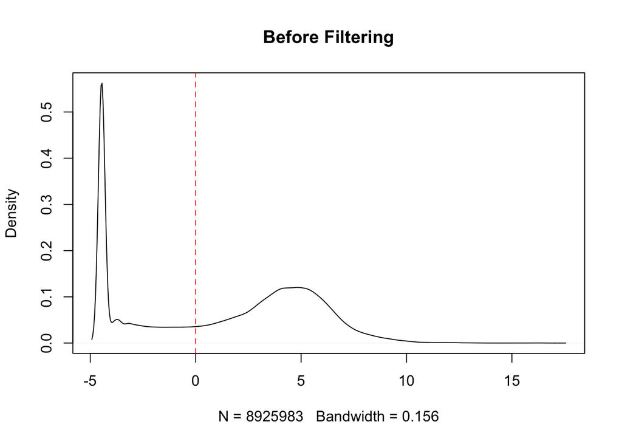

```r
plot(density(logcpm),main="Before Filtering")#,xlim=c(-10,20000))
abline(v =0, col = "red", lty = 2)
```

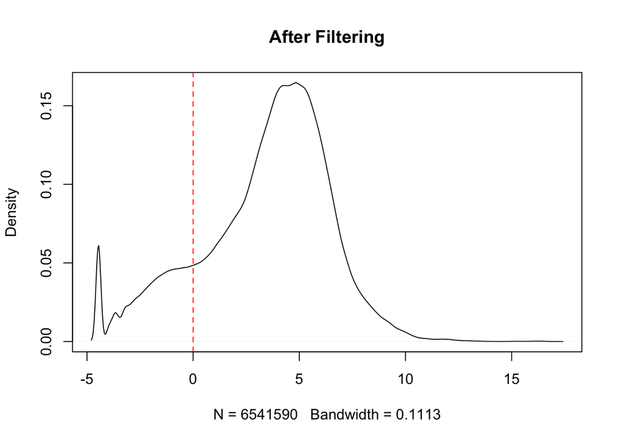

```r
plot(density(logcpm_filt),main="After Filtering")#,xlim=c(-10,20000))
abline(v =0, col = "red", lty = 2)
```

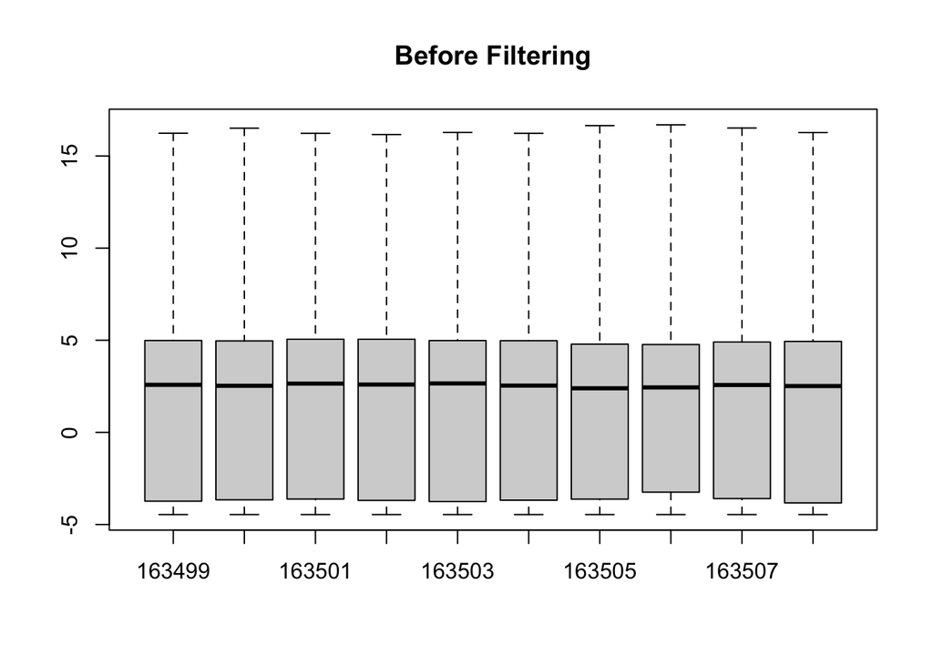

```r
# Calculate Normalization Factors
y_Final  <- calcNormFactors(y_Filtered,method="TMM") # This is the default
LogCPM_Final <- cpm(y_Final$counts, log=T)


#Plot to make sure everything is normalized
#Before Filtering
boxplot(logcpm[,1:10], main="Before Filtering")
```

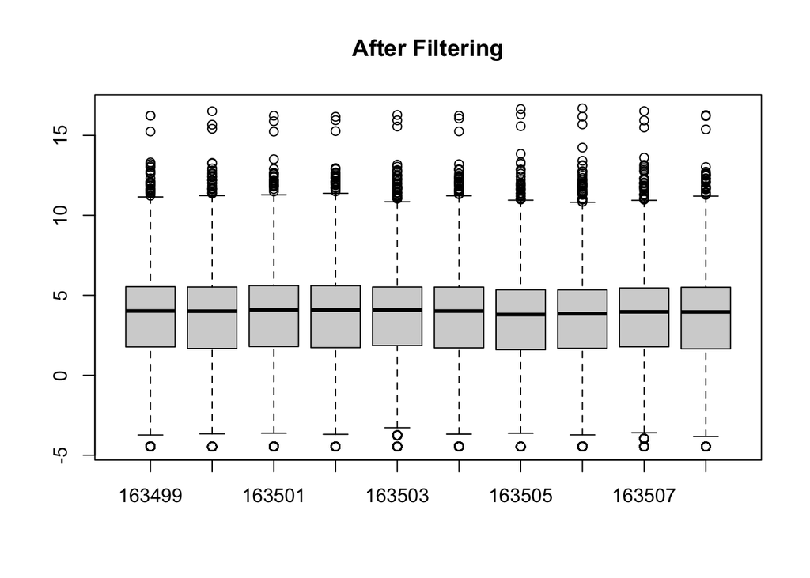

```r
#After Filtering
boxplot(logcpm_filt[,1:10], main="After Filtering")
```

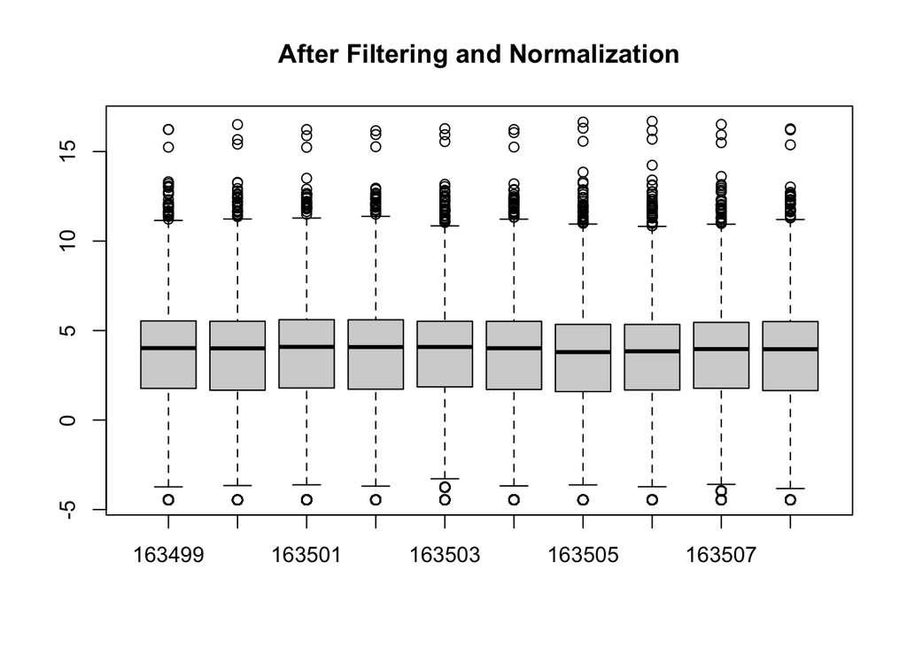

```r
#After filtering and normalization
boxplot(LogCPM_Final[,1:10], main="After Filtering and Normalization")
```

## Quality Control: Principle Components Analysis

Performing a PCA and then testing association of covariates with PCs

```r
PCobj =prcomp(t(LogCPM_Final), scale=TRUE)
PCs = PCobj$x
PCs =as.data.frame(PCs[,1:4])
colnames(PCs)<-c("PC1","PC2","PC3","PC4")


CranioCovariates_PCs<-merge(CranioCovariates, PCs,by='row.names')
rownames(CranioCovariates_PCs)<-CranioCovariates_PCs[,1]
CranioCovariates_PCs<-CranioCovariates_PCs[,-1]


EVAL<-as.data.frame(matrix(NA,nrow=4,ncol=7))
colnames(EVAL)<-c("P_Phenotype","P_Cohort", "P_Origin", "P_Sex", "P_ProbandAge", "P_CultureTime", "P_Case")
for (i in 1:4){
  AOV<-aov(PCs[,i]~Phenotype,data=CranioCovariates_PCs)
  EVAL[i,1] <-summary(AOV)[[1]][["Pr(>F)"]][1]
}

for (i in 1:4){
  AOV<-aov(PCs[,i]~Cohort,data=CranioCovariates_PCs)
  EVAL[i,2] <-summary(AOV)[[1]][["Pr(>F)"]][1]
}

for (i in 1:4){
  AOV<-aov(PCs[,i]~Origin,data=CranioCovariates_PCs)
  EVAL[i,3] <-summary(AOV)[[1]][["Pr(>F)"]][1]
}
for (i in 1:4){
  AOV<-aov(PCs[,i]~Sex,data=CranioCovariates_PCs)
  EVAL[i,4] <-summary(AOV)[[1]][["Pr(>F)"]][1]
}
for (i in 1:4){
  AOV<-aov(PCs[,i]~Proband_Age,data=CranioCovariates_PCs)
  EVAL[i,5] <-summary(AOV)[[1]][["Pr(>F)"]][1]
}
for (i in 1:4){
  AOV<-aov(PCs[,i]~Culture_Time,data=CranioCovariates_PCs)
  EVAL[i,6] <-summary(AOV)[[1]][["Pr(>F)"]][1]
}
for (i in 1:4){
  AOV<-aov(PCs[,i]~Case_Control,data=CranioCovariates_PCs)
  EVAL[i,7] <-summary(AOV)[[1]][["Pr(>F)"]][1]
}
EVAL$PropVar = summary(PCobj)$importance["Proportion of Variance", 1:4]
print(EVAL)
```

```
##    P_Phenotype     P_Cohort     P_Origin      P_Sex P_ProbandAge P_CultureTime
## 1 2.123826e-07 1.673808e-01 4.150527e-01 0.06901714 2.649371e-01  3.377896e-07
## 2 9.465590e-01 1.079093e-27 3.143787e-06 0.30806416 5.506224e-05  1.367158e-18
## 3 4.517996e-01 4.962050e-37 1.228025e-07 0.54402979 4.528652e-01  1.352551e-13
## 4 6.020150e-03 1.232674e-01 3.568182e-01 0.41390851 7.289429e-07  2.384473e-08
##       P_Case PropVar
## 1 0.46580328 0.21060
## 2 0.84623528 0.11928
## 3 0.07770667 0.07200
## 4 0.02878526 0.05218
```

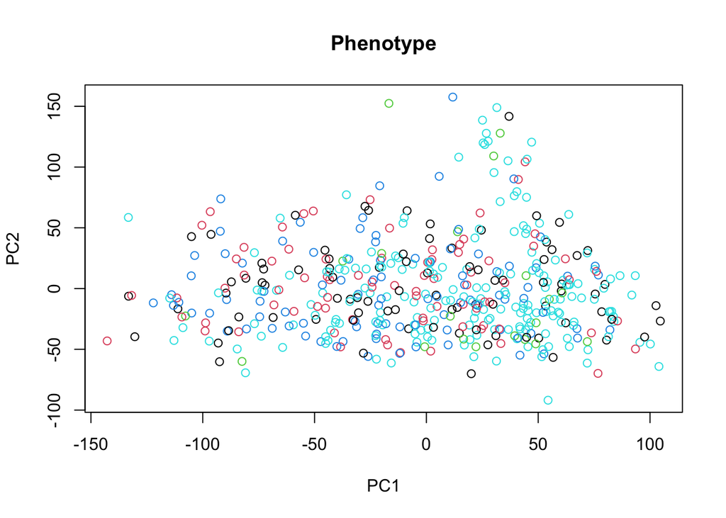

```r
#Coloring by Variables associated with PC1 or PC2
#PC2 v PC1-Coloring by Phenotype
plot(PCs$PC1,PCs$PC2,col=as.factor(CranioCovariates_PCs$Phenotype),xlab="PC1",ylab="PC2", main="Phenotype")
```

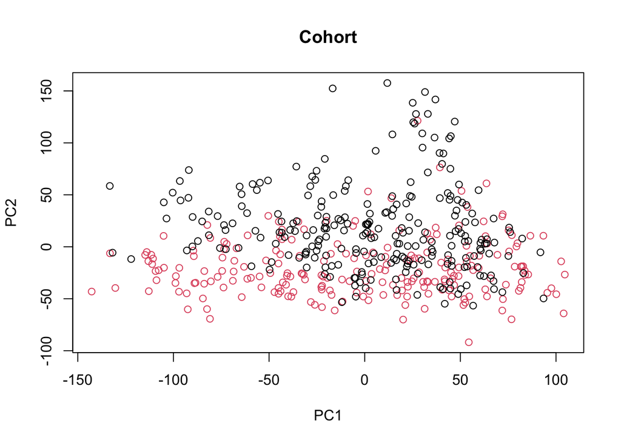

```r
#PC2 v PC1- Colored by Cohort
plot(PCs$PC1,PCs$PC2,col=CranioCovariates_PCs$Cohort,xlab="PC1",ylab="PC2", main="Cohort")
```

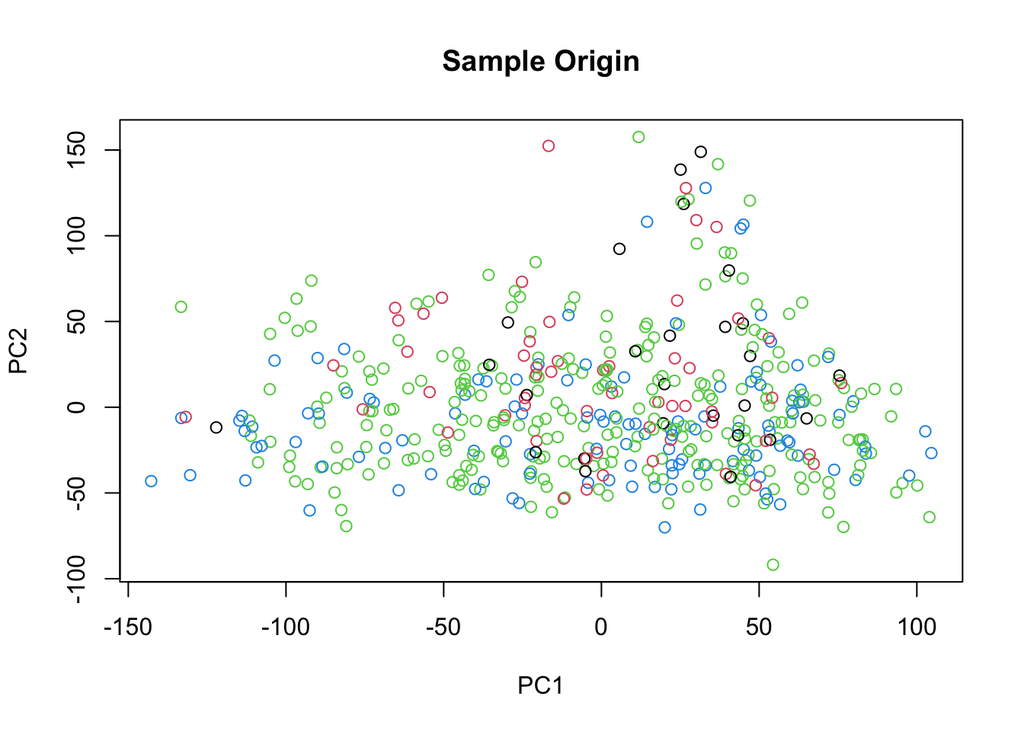

```r
#PC2 v PC1- Colored by Sample Origin
plot(PCs$PC1,PCs$PC2,col=as.factor(CranioCovariates_PCs$Origin),xlab="PC1",ylab="PC2", main="Sample Origin")
```

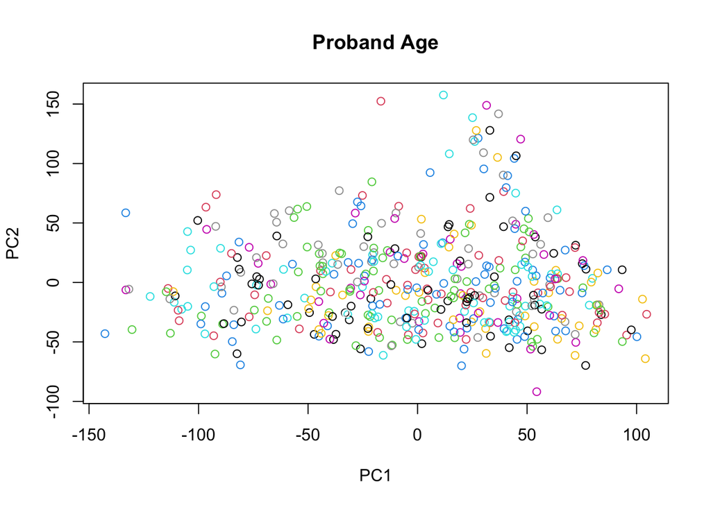

```r
#PC2 v PC1- Colored by Proband Age
plot(PCs$PC1,PCs$PC2,col=CranioCovariates_PCs$Proband_Age,xlab="PC1",ylab="PC2", main="Proband Age")
```

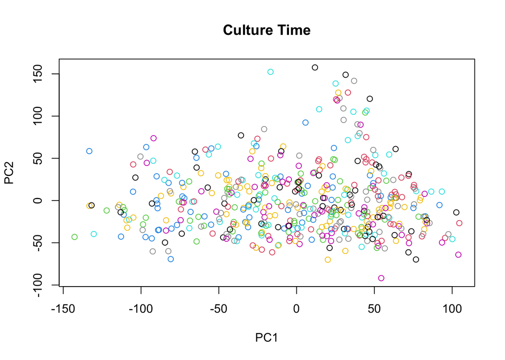

```r
#PC2 v PC1- Colored by Culture Time
plot(PCs$PC1,PCs$PC2,col=CranioCovariates_PCs$Culture_Time,xlab="PC1",ylab="PC2", main="Culture Time")
```

## Save Data

```r
save(CranioCovariates, y_Final, file="/Volumes/paquette_a/slapehn/CranioRNAseq/CranioRNAseq_FilteredNormalized.RData")
```